# Week 06: Naive Bayes Classifiers

Ziyuan Huang

Last Updated: April 16, 2026

```r
library(seedhash)
gen <- SeedHashGenerator$new("ANLY530-Week06-NaiveBayes")
MASTER_SEED <- gen$generate_seeds(1)
set.seed(MASTER_SEED)
```

**Random Seed Source:** `seedhash` package — input string: `"ANLY530-Week06-NaiveBayes"` → seed: `-120589735`

# Introduction

Over the past five weeks we have built classifiers that work very differently:

- **Decision Trees** ask a series of yes/no questions about features.
- **Random Forests** average hundreds of trees to reduce variance.
- **SVMs** find the widest possible gap between classes.

This week we take yet another approach — one rooted in **probability**. Instead of drawing boundaries or asking questions, a **Naive Bayes classifier** asks: *“Given what I see, what is the most probable class?”*

The idea is surprisingly simple. You start with a rough guess about how common each class is (the **prior**). Then, for every piece of evidence you observe, you update that guess using **Bayes’ Theorem**. The word “naive” comes from a bold simplifying assumption: **every feature is independent of every other feature**, given the class. This assumption is almost never true in reality — yet the classifier works remarkably well anyway.

> *“Naive Bayes methods are a set of supervised learning algorithms based on applying Bayes’ theorem with the ‘naive’ assumption of conditional independence between every pair of features given the value of the class variable.”* — scikit-learn documentation **[1]**

> *“Despite their naive design and apparently oversimplified assumptions, naive Bayes classifiers have worked quite well in many complex real-world situations.”* — Wikipedia, “Naive Bayes classifier” **[2]**

**Learning Objectives:**

1. Understand **Bayes’ Theorem** and its four components: prior, likelihood, evidence, and posterior.
2. Explain the **naive independence assumption** and why the classifier still works despite it.
3. Distinguish between **Gaussian**, **Multinomial**, and **Bernoulli** Naive Bayes and know when to use each.
4. Build, evaluate, and visualise a Naive Bayes classifier in R using the `e1071` package.
5. Understand the **zero-frequency problem** and how **Laplace smoothing** fixes it.
6. Compare Naive Bayes to Decision Trees, Random Forests, and SVMs on the same dataset.
7. Apply Naive Bayes to a **text classification** (spam filtering) task.

## Required Packages

```r
if (!require("pacman")) install.packages("pacman")
pacman::p_load(
  tidyverse,
  e1071,
  caret,
  gridExtra,
  scales,
  rpart,
  randomForest,
  knitr,
  kableExtra
)
```

```
##
##  C:\Users\roozb\AppData\Local\Temp\Rtmp4ohGum\downloaded_packages
```

# Part 1: Bayes’ Theorem — Updating Your Beliefs

## 1.1 An Everyday Example: Is This Email Spam?

Imagine your email inbox. About 20% of all incoming messages are spam. You receive a new message containing the word **“Urgent”**. Should you be worried?

Here is what you know:

- **Prior belief:** 20% of all email is spam → $P(\text{spam}) = 0.20$
- **Likelihood:** 60% of spam emails contain the word “Urgent” → $P(\text{Urgent} \mid \text{spam}) = 0.60$
- **Overall:** Only 15% of *all* emails contain “Urgent” → $P(\text{Urgent}) = 0.15$

Bayes’ Theorem lets you **update** your prior belief using the new evidence:

$$P(\text{spam} \mid \text{Urgent}) =
\frac{P(\text{Urgent} \mid \text{spam}) \times
P(\text{spam})}{P(\text{Urgent})} = \frac{0.60 \times 0.20}{0.15} =
0.80$$

After seeing the word “Urgent”, your belief that this email is spam jumps from 20% to **80%**. That is the power of Bayes’ Theorem — it turns prior knowledge plus new evidence into an updated, more informed belief.

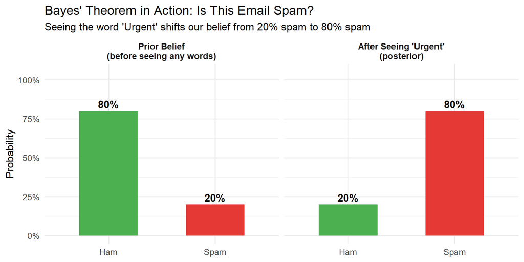

```r
spam_df <- data.frame(
  Stage   = factor(c("Prior Belief\n(before seeing any words)",
                      "After Seeing 'Urgent'\n(posterior)"),
                   levels = c("Prior Belief\n(before seeing any words)",
                              "After Seeing 'Urgent'\n(posterior)")),
  Spam    = c(0.20, 0.80),
  Ham     = c(0.80, 0.20)
) %>%
  pivot_longer(cols = c(Spam, Ham), names_to = "Class", values_to = "Probability")

ggplot(spam_df, aes(x = Class, y = Probability, fill = Class)) +
  geom_col(width = 0.55) +
  geom_text(aes(label = scales::percent(Probability, accuracy = 1)),
            vjust = -0.4, fontface = "bold", size = 4.5) +
  facet_wrap(~ Stage) +
  scale_fill_manual(values = c(Ham = "#4CAF50", Spam = "#E53935")) +
  scale_y_continuous(labels = scales::percent, limits = c(0, 1.05)) +
  labs(
    title = "Bayes' Theorem in Action: Is This Email Spam?",
    subtitle = "Seeing the word 'Urgent' shifts our belief from 20% spam to 80% spam",
    x = NULL, y = "Probability"
  ) +
  theme_minimal(base_size = 13) +
  theme(legend.position = "none",
        strip.text = element_text(face = "bold", size = 11))
```

## 1.2 The Four Components of Bayes’ Theorem

$$P(C \mid X) = \frac{P(X \mid C) \times
P(C)}{P(X)}$$

Every term has a name and a plain-English meaning:

The Four Components of Bayes’ Theorem

| Symbol | Name | Plain English |
| --- | --- | --- |
| $P(C)$ | Prior | How common is this class *before* we look at any features? (Our initial guess.) |
| $P(X \mid C)$ | Likelihood | If the class really is C, how likely are we to see these particular feature values? |
| $P(X)$ | Evidence (Marginal) | How likely are these feature values across *all* classes? (A normalising constant.) |
| $P(C \mid X)$ | Posterior | After seeing the features, how probable is class C? (Our updated, informed belief.) |

> **Key insight:** The **evidence** $P(X)$ is the same for every class. When comparing classes, it cancels out. So in practice we only need:
> $$P(C \mid X) \propto P(X \mid C) \times
> P(C)$$
> Pick the class with the **largest numerator** — that is the prediction.

## 1.3 A Visual Walk-Through: From Prior to Posterior

Let’s visualise the full Bayesian update for three competing classes. Imagine a doctor diagnosing a patient with symptoms $X$. There are three possible diseases, each with a different prior probability and a different likelihood of producing these symptoms.

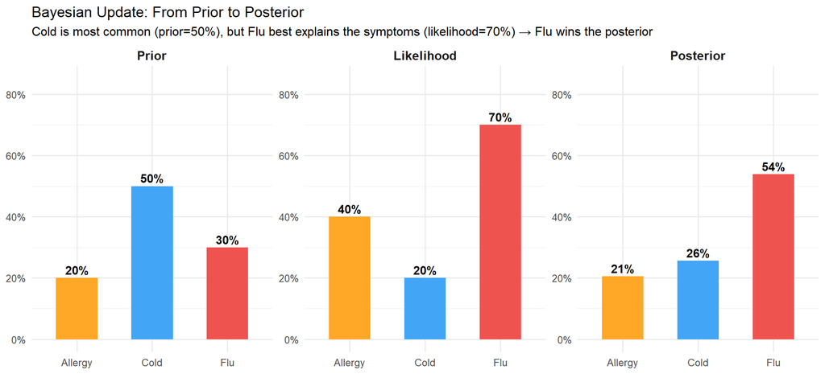

```r
diseases <- data.frame(
  Disease    = c("Cold", "Flu", "Allergy"),
  Prior      = c(0.50, 0.30, 0.20),
  Likelihood = c(0.20, 0.70, 0.40)
)
diseases$Numerator <- diseases$Prior * diseases$Likelihood
diseases$Posterior <- diseases$Numerator / sum(diseases$Numerator)

diseases_long <- diseases %>%
  select(Disease, Prior, Likelihood, Posterior) %>%
  pivot_longer(-Disease, names_to = "Component", values_to = "Value") %>%
  mutate(Component = factor(Component, levels = c("Prior", "Likelihood", "Posterior")))

ggplot(diseases_long, aes(x = Disease, y = Value, fill = Disease)) +
  geom_col(width = 0.55) +
  geom_text(aes(label = sprintf("%.0f%%", Value * 100)),
            vjust = -0.4, fontface = "bold", size = 4) +
  facet_wrap(~ Component, scales = "free_y") +
  scale_fill_manual(values = c(Cold = "#42A5F5", Flu = "#EF5350", Allergy = "#FFA726")) +
  scale_y_continuous(labels = scales::percent, limits = c(0, 0.85)) +
  labs(
    title = "Bayesian Update: From Prior to Posterior",
    subtitle = "Cold is most common (prior=50%), but Flu best explains the symptoms (likelihood=70%) → Flu wins the posterior",
    x = NULL, y = NULL
  ) +
  theme_minimal(base_size = 12) +
  theme(legend.position = "none",
        strip.text = element_text(face = "bold", size = 12))
```

> Even though Cold is the most common disease (highest prior), the Flu’s much higher likelihood of producing these symptoms makes it the most probable diagnosis after we consider the evidence.

# Part 2: The “Play Tennis” Example — Naive Bayes by Hand

## 2.1 The Dataset

This is a classic dataset from the lecture. We have 14 days of weather observations and whether someone chose to play tennis.

```r
tennis <- data.frame(
  Day       = 1:14,
  Outlook   = c("Sunny","Sunny","Overcast","Rain","Rain","Rain","Overcast",
                 "Sunny","Sunny","Rain","Sunny","Overcast","Overcast","Rain"),
  Temp      = c("Hot","Hot","Hot","Mild","Cool","Cool","Cool",
                 "Mild","Cool","Mild","Mild","Mild","Hot","Mild"),
  Humidity  = c("High","High","High","High","Normal","Normal","Normal",
                 "High","Normal","Normal","Normal","High","Normal","High"),
  Windy     = c("No","Yes","No","No","No","Yes","Yes",
                 "No","No","No","Yes","Yes","No","Yes"),
  Play      = c("No","No","Yes","Yes","Yes","No","Yes",
                 "No","Yes","Yes","Yes","Yes","Yes","No")
)
knitr::kable(tennis, caption = "The Play Tennis Dataset (14 observations)")
```

The Play Tennis Dataset (14 observations)

| Day | Outlook | Temp | Humidity | Windy | Play |
| --- | --- | --- | --- | --- | --- |
| 1 | Sunny | Hot | High | No | No |
| 2 | Sunny | Hot | High | Yes | No |
| 3 | Overcast | Hot | High | No | Yes |
| 4 | Rain | Mild | High | No | Yes |
| 5 | Rain | Cool | Normal | No | Yes |
| 6 | Rain | Cool | Normal | Yes | No |
| 7 | Overcast | Cool | Normal | Yes | Yes |
| 8 | Sunny | Mild | High | No | No |
| 9 | Sunny | Cool | Normal | No | Yes |
| 10 | Rain | Mild | Normal | No | Yes |
| 11 | Sunny | Mild | Normal | Yes | Yes |
| 12 | Overcast | Mild | High | Yes | Yes |
| 13 | Overcast | Hot | Normal | No | Yes |
| 14 | Rain | Mild | High | Yes | No |

## 2.2 Computing Frequency Tables

To apply Naive Bayes, we first count how often each feature value appears for each class.

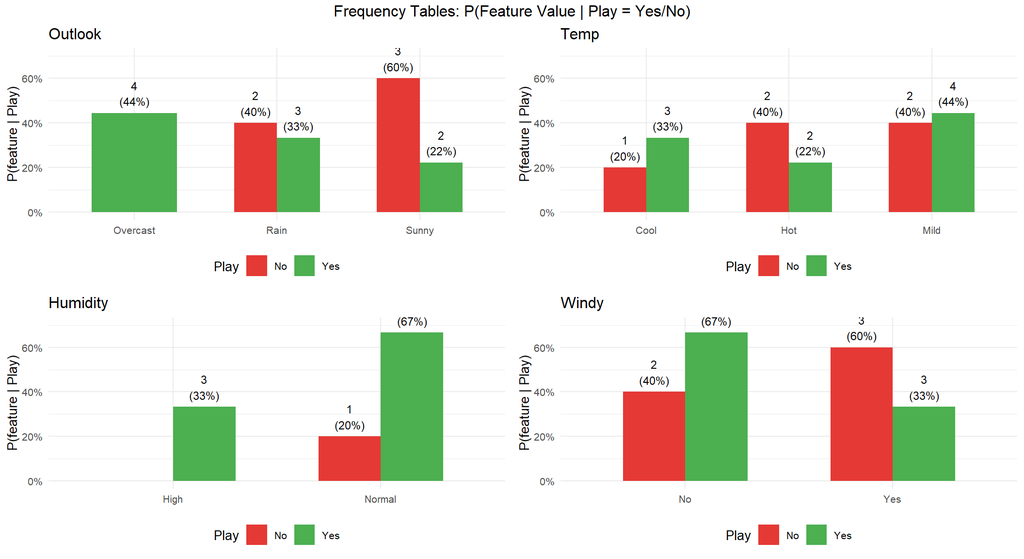

```r
features <- c("Outlook", "Temp", "Humidity", "Windy")

freq_plots <- lapply(features, function(feat) {
  freq_df <- tennis %>%
    count(!!sym(feat), Play) %>%
    group_by(Play) %>%
    mutate(Proportion = n / sum(n))

  ggplot(freq_df, aes(x = !!sym(feat), y = Proportion, fill = Play)) +
    geom_col(position = "dodge", width = 0.6) +
    geom_text(aes(label = sprintf("%d\n(%.0f%%)", n, Proportion * 100)),
              position = position_dodge(width = 0.6), vjust = -0.3, size = 3) +
    scale_fill_manual(values = c(Yes = "#4CAF50", No = "#E53935")) +
    scale_y_continuous(limits = c(0, 0.7), labels = scales::percent) +
    labs(title = feat, x = NULL, y = "P(feature | Play)") +
    theme_minimal(base_size = 10) +
    theme(legend.position = "bottom")
})

do.call(grid.arrange, c(freq_plots, ncol = 2,
  top = "Frequency Tables: P(Feature Value | Play = Yes/No)"))
```

> **How to read:** Each bar shows the proportion of times a feature value appears *within* each class. For example, when Play = Yes, “Overcast” accounts for 4 out of 9 days (44%).

## 2.3 Manual Prediction: Should We Play Today?

Suppose today’s weather is: **Outlook = Sunny, Temp = Cool, Humidity = High, Windy = Yes**.

We compute the **numerator** for each class:

$$P(\text{Yes} \mid X) \propto P(X \mid
\text{Yes}) \times P(\text{Yes})$$
$$P(\text{No} \mid X) \propto P(X \mid \text{No})
\times P(\text{No})$$

Using the naive independence assumption, $P(X \mid C)$ becomes a product:

$$P(X \mid C) = P(\text{Sunny} \mid C)
\times P(\text{Cool} \mid C) \times P(\text{High} \mid C) \times
P(\text{Yes(Windy)} \mid C)$$

```r
yes_count <- sum(tennis$Play == "Yes")  # 9
no_count  <- sum(tennis$Play == "No")   # 5
total     <- nrow(tennis)               # 14

prior_yes <- yes_count / total
prior_no  <- no_count / total

tennis_yes <- tennis[tennis$Play == "Yes", ]
tennis_no  <- tennis[tennis$Play == "No", ]

# P(feature | Play = Yes)
p_sunny_yes <- sum(tennis_yes$Outlook == "Sunny") / yes_count
p_cool_yes  <- sum(tennis_yes$Temp == "Cool") / yes_count
p_high_yes  <- sum(tennis_yes$Humidity == "High") / yes_count
p_windy_yes <- sum(tennis_yes$Windy == "Yes") / yes_count

# P(feature | Play = No)
p_sunny_no <- sum(tennis_no$Outlook == "Sunny") / no_count
p_cool_no  <- sum(tennis_no$Temp == "Cool") / no_count
p_high_no  <- sum(tennis_no$Humidity == "High") / no_count
p_windy_no <- sum(tennis_no$Windy == "Yes") / no_count

numerator_yes <- p_sunny_yes * p_cool_yes * p_high_yes * p_windy_yes * prior_yes
numerator_no  <- p_sunny_no * p_cool_no * p_high_no * p_windy_no * prior_no

posterior_yes <- numerator_yes / (numerator_yes + numerator_no)
posterior_no  <- numerator_no / (numerator_yes + numerator_no)

cat("--- Likelihoods ---\n")
```

```
## --- Likelihoods ---
```

```r
cat(sprintf("P(X | Yes) = %.4f × %.4f × %.4f × %.4f = %.6f\n",
            p_sunny_yes, p_cool_yes, p_high_yes, p_windy_yes,
            p_sunny_yes * p_cool_yes * p_high_yes * p_windy_yes))
```

```
## P(X | Yes) = 0.2222 × 0.3333 × 0.3333 × 0.3333 = 0.008230
```

```r
cat(sprintf("P(X | No)  = %.4f × %.4f × %.4f × %.4f = %.6f\n\n",
            p_sunny_no, p_cool_no, p_high_no, p_windy_no,
            p_sunny_no * p_cool_no * p_high_no * p_windy_no))
```

```
## P(X | No)  = 0.6000 × 0.2000 × 0.8000 × 0.6000 = 0.057600
```

```r
cat("--- Numerators (Likelihood × Prior) ---\n")
```

```
## --- Numerators (Likelihood × Prior) ---
```

```r
cat(sprintf("Score(Yes) = %.6f × %.4f = %.6f\n",
            p_sunny_yes * p_cool_yes * p_high_yes * p_windy_yes, prior_yes, numerator_yes))
```

```
## Score(Yes) = 0.008230 × 0.6429 = 0.005291
```

```r
cat(sprintf("Score(No)  = %.6f × %.4f = %.6f\n\n",
            p_sunny_no * p_cool_no * p_high_no * p_windy_no, prior_no, numerator_no))
```

```
## Score(No)  = 0.057600 × 0.3571 = 0.020571
```

```r
cat("--- Posterior Probabilities ---\n")
```

```
## --- Posterior Probabilities ---
```

```r
cat(sprintf("P(Yes | X) = %.4f (%.1f%%)\n", posterior_yes, posterior_yes * 100))
```

```
## P(Yes | X) = 0.2046 (20.5%)
```

```r
cat(sprintf("P(No  | X) = %.4f (%.1f%%)\n\n", posterior_no, posterior_no * 100))
```

```
## P(No  | X) = 0.7954 (79.5%)
```

```r
cat(sprintf("Prediction: %s\n", ifelse(posterior_yes > posterior_no, "Play Tennis!", "Don't Play")))
```

```
## Prediction: Don't Play
```

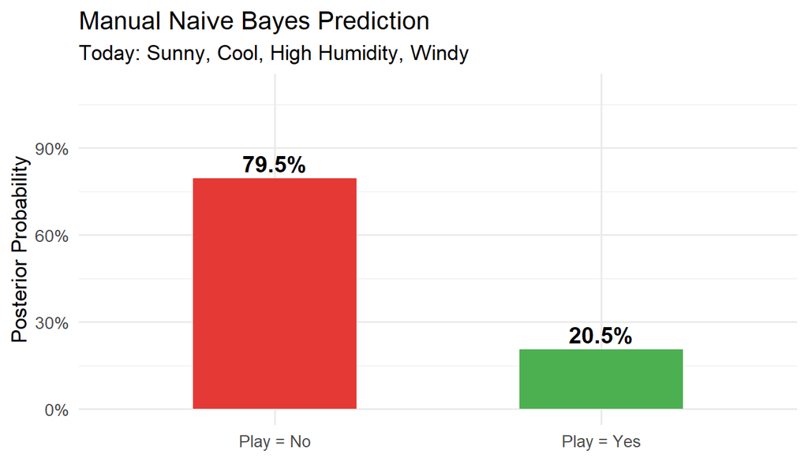

```r
manual_df <- data.frame(
  Class = c("Play = Yes", "Play = No"),
  Posterior = c(posterior_yes, posterior_no)
)

ggplot(manual_df, aes(x = Class, y = Posterior, fill = Class)) +
  geom_col(width = 0.5) +
  geom_text(aes(label = sprintf("%.1f%%", Posterior * 100)),
            vjust = -0.4, fontface = "bold", size = 5) +
  scale_fill_manual(values = c("Play = Yes" = "#4CAF50", "Play = No" = "#E53935")) +
  scale_y_continuous(labels = scales::percent, limits = c(0, 1.1)) +
  labs(
    title = "Manual Naive Bayes Prediction",
    subtitle = "Today: Sunny, Cool, High Humidity, Windy",
    x = NULL, y = "Posterior Probability"
  ) +
  theme_minimal(base_size = 13) +
  theme(legend.position = "none")
```

# Part 3: The Naive Assumption — Why “Naive”?

## 3.1 Conditional Independence: The Bold Simplification

The full Bayes formula requires computing $P(X \mid C)$ — the probability of seeing *all* features together, given a class. For $n$ features, this joint probability has an astronomical number of combinations to estimate.

The **naive** assumption says: *given the class, every feature is independent of every other feature*. Mathematically:

$$P(x_1, x_2, \ldots, x_n \mid C) =
\prod_{i=1}^{n} P(x_i \mid C)$$

This turns one impossibly complex probability into a simple **product of $n$ easy-to-estimate probabilities**.

**Analogy:** Imagine predicting whether a student will pass an exam. Features include hours studied, hours slept, and cups of coffee. In reality, someone who studied many hours probably slept fewer hours and drank more coffee — the features are correlated. The naive assumption pretends these are unrelated, treating each one separately. It sounds absurd, but it works surprisingly well because:

1. Even if individual probabilities are slightly off, the **ranking** of classes often stays correct.
2. Errors in one feature’s estimate tend to be offset by errors in another.
3. The classifier only needs to get the **most probable class** right, not the exact probability value.

## 3.2 Are Features Really Independent? (Spoiler: No)

Let’s check with the Iris dataset — the same one we’ve used in previous weeks.

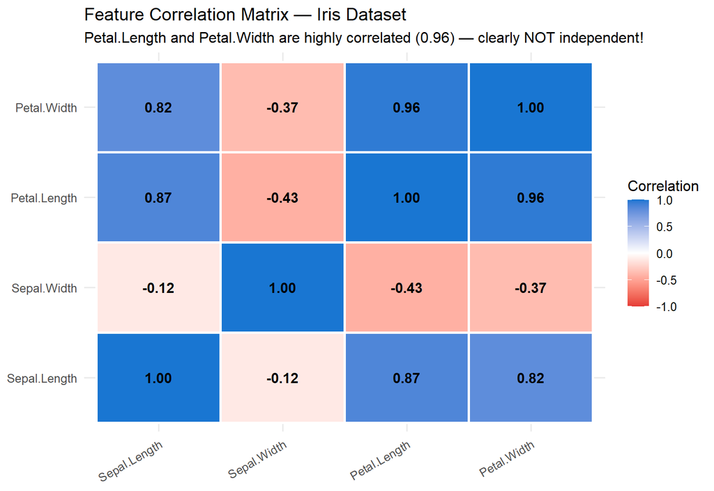

```r
data(iris)

cor_mat <- cor(iris[, 1:4])

cor_df <- as.data.frame(as.table(cor_mat))
names(cor_df) <- c("Feature1", "Feature2", "Correlation")

ggplot(cor_df, aes(x = Feature1, y = Feature2, fill = Correlation)) +
  geom_tile(color = "white", linewidth = 1) +
  geom_text(aes(label = sprintf("%.2f", Correlation)),
            color = "black", size = 4, fontface = "bold") +
  scale_fill_gradient2(low = "#E53935", mid = "white", high = "#1976D2",
                       midpoint = 0, limits = c(-1, 1)) +
  labs(
    title = "Feature Correlation Matrix — Iris Dataset",
    subtitle = "Petal.Length and Petal.Width are highly correlated (0.96) — clearly NOT independent!",
    x = NULL, y = NULL
  ) +
  theme_minimal(base_size = 12) +
  theme(axis.text.x = element_text(angle = 30, hjust = 1))
```

> **Petal.Length and Petal.Width have a correlation of 0.96** — nearly perfectly correlated. The naive independence assumption is clearly violated. Yet, as we will see shortly, Naive Bayes still achieves excellent accuracy on this dataset. This is why the method is both “naive” and surprisingly effective.

## 3.3 Why Does It Work Anyway?

Why Naive Bayes Works Despite the Independence Assumption

| Reason | Explanation |
| --- | --- |
| Classification only needs the correct ranking | NB doesn’t need perfect probability estimates — it just needs the correct class to have the HIGHEST score. Even biased estimates often preserve the right ordering. |
| Estimation errors cancel out | If P(x₁\|C) is overestimated and P(x₂\|C) is underestimated, the product can still be approximately correct. |
| Simple models generalise well | With fewer parameters than complex models, NB is less prone to overfitting, especially with small training sets. |
| Few parameters to estimate | For p features and K classes, NB estimates only p×K parameters. A full joint model would need K × (exponential in p) parameters. |

# Part 4: Types of Naive Bayes Classifiers

Different types of data call for different assumptions about how feature values are distributed within each class. This is what distinguishes the three main Naive Bayes variants.

## 4.1 Gaussian Naive Bayes — For Continuous Features

When features are continuous (like height, weight, or petal length), we assume each feature follows a **normal (Gaussian) distribution** within each class:

$$P(x_i \mid C_k) =
\frac{1}{\sqrt{2\pi\sigma_{k}^2}} \exp\left(-\frac{(x_i -
\mu_{k})^2}{2\sigma_{k}^2}\right)$$

In plain English: for each class, we compute the **mean** ($\mu$) and **standard deviation** ($\sigma$) of each feature. To evaluate a new data point, we ask: *“How likely is this value under each class’s bell curve?”*

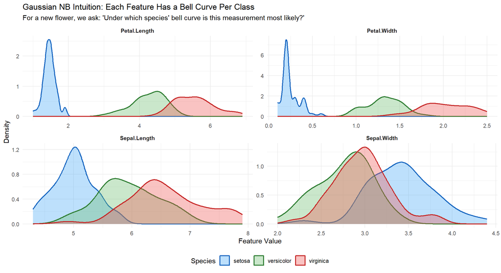

```r
set.seed(MASTER_SEED)

iris_long <- iris %>%
  pivot_longer(cols = 1:4, names_to = "Feature", values_to = "Value")

ggplot(iris_long, aes(x = Value, fill = Species, color = Species)) +
  geom_density(alpha = 0.35, linewidth = 0.8) +
  facet_wrap(~ Feature, scales = "free", ncol = 2) +
  scale_fill_manual(values = c(setosa = "#42A5F5", versicolor = "#66BB6A", virginica = "#EF5350")) +
  scale_color_manual(values = c(setosa = "#1565C0", versicolor = "#2E7D32", virginica = "#C62828")) +
  labs(
    title = "Gaussian NB Intuition: Each Feature Has a Bell Curve Per Class",
    subtitle = "For a new flower, we ask: 'Under which species' bell curve is this measurement most likely?'",
    x = "Feature Value", y = "Density"
  ) +
  theme_minimal(base_size = 11) +
  theme(legend.position = "bottom",
        strip.text = element_text(face = "bold"))
```

## 4.2 How Gaussian NB Makes a Decision — Feature by Feature

Let’s zoom into a single test prediction and see how each feature contributes.

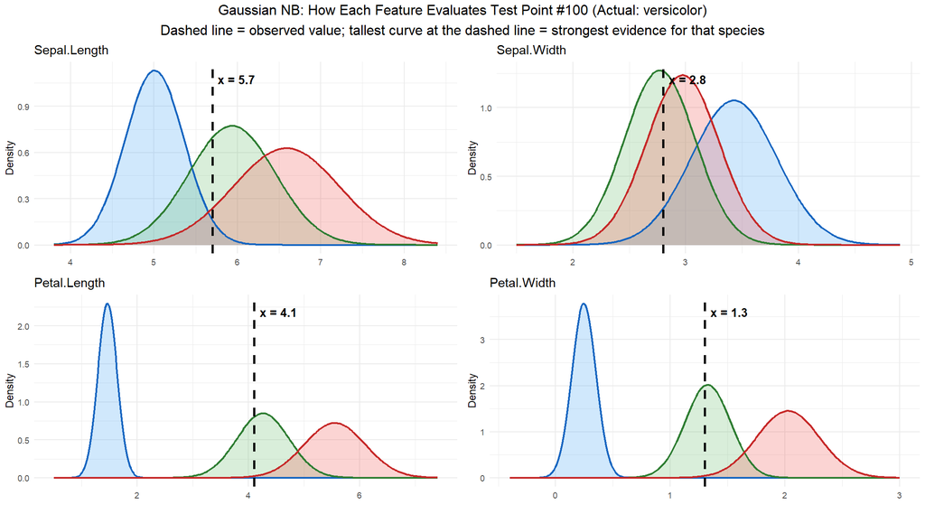

```r
set.seed(MASTER_SEED)
test_point <- iris[100, ]  # a versicolor

stats_df <- iris %>%
  group_by(Species) %>%
  summarise(across(1:4, list(mean = mean, sd = sd), .names = "{.col}_{.fn}"))

feature_names <- names(iris)[1:4]
species_levels <- levels(iris$Species)

contrib_list <- lapply(feature_names, function(feat) {
  x_val <- test_point[[feat]]
  x_range <- seq(min(iris[[feat]]) - 0.5, max(iris[[feat]]) + 0.5, length.out = 300)

  curves <- lapply(species_levels, function(sp) {
    mu <- stats_df[[paste0(feat, "_mean")]][stats_df$Species == sp]
    sg <- stats_df[[paste0(feat, "_sd")]][stats_df$Species == sp]
    data.frame(x = x_range, density = dnorm(x_range, mu, sg), Species = sp)
  }) %>% do.call(rbind, .)

  densities_at_x <- sapply(species_levels, function(sp) {
    mu <- stats_df[[paste0(feat, "_mean")]][stats_df$Species == sp]
    sg <- stats_df[[paste0(feat, "_sd")]][stats_df$Species == sp]
    dnorm(x_val, mu, sg)
  })

  ggplot(curves, aes(x = x, y = density, fill = Species, color = Species)) +
    geom_area(alpha = 0.25, position = "identity") +
    geom_line(linewidth = 0.8) +
    geom_vline(xintercept = x_val, linetype = "dashed", linewidth = 1, color = "black") +
    annotate("text", x = x_val, y = max(curves$density) * 0.95,
             label = sprintf("x = %.1f", x_val),
             hjust = -0.15, fontface = "bold", size = 3.5) +
    scale_fill_manual(values = c(setosa = "#42A5F5", versicolor = "#66BB6A", virginica = "#EF5350")) +
    scale_color_manual(values = c(setosa = "#1565C0", versicolor = "#2E7D32", virginica = "#C62828")) +
    labs(title = feat, x = NULL, y = "Density") +
    theme_minimal(base_size = 9) +
    theme(legend.position = "none")
})

do.call(grid.arrange, c(contrib_list, ncol = 2,
  top = sprintf("Gaussian NB: How Each Feature Evaluates Test Point #100 (Actual: %s)\nDashed line = observed value; tallest curve at the dashed line = strongest evidence for that species",
                as.character(test_point$Species))))
```

## 4.3 Multinomial Naive Bayes — For Count Data

When features represent **counts** or **frequencies** (such as word counts in a document), we use the Multinomial distribution:

$$P(\mathbf{x} \mid C_k) = \frac{(\sum_i
x_i)!}{\prod_i x_i!} \prod_{i=1}^{n} p_{ki}^{x_i}$$

This is the go-to model for **text classification**. Each document is represented as a vector of word frequencies (the “bag of words” model), and the classifier learns which words are most frequent in each category.

## 4.4 Bernoulli Naive Bayes — For Binary Features

When features are **binary** (present/absent, yes/no, 0/1), we use the Bernoulli distribution:

$$P(\mathbf{x} \mid C_k) = \prod_{i=1}^{n}
p_{ki}^{x_i} (1 - p_{ki})^{(1 - x_i)}$$

Unlike Multinomial NB, Bernoulli NB explicitly models the **absence** of features. This makes it especially useful for short text classification where knowing a word is *missing* is informative.

## 4.5 Comparison: When to Use Which?

Naive Bayes Variants: Which One to Use?

| Variant | Feature Type | Typical Use Case | Key Assumption | R / Python |
| --- | --- | --- | --- | --- |
| Gaussian NB | Continuous (real-valued) | Sensor readings, measurements, medical data | Features follow a normal distribution within each class | e1071::naiveBayes() / GaussianNB |
| Multinomial NB | Counts / Frequencies | Text classification (word counts), spam filtering | Features are generated by a multinomial distribution | Not in e1071 (use quanteda) / MultinomialNB |
| Bernoulli NB | Binary (0/1) | Short text classification, survey data (yes/no) | Features are binary; explicitly penalises absent features | Not in e1071 (custom) / BernoulliNB |

# Part 5: Gaussian Naive Bayes on Iris — Building the Model

## 5.1 Train/Test Split

We use the same Iris dataset and the same split ratio as previous weeks for a fair comparison.

```r
data(iris)
set.seed(MASTER_SEED)
train_idx <- sample(1:nrow(iris), floor(0.7 * nrow(iris)))
iris_train <- iris[train_idx, ]
iris_test  <- iris[-train_idx, ]

cat(sprintf("Training set: %d observations\nTest set: %d observations\n",
            nrow(iris_train), nrow(iris_test)))
```

```
## Training set: 105 observations
## Test set: 45 observations
```

## 5.2 Training the Classifier

R’s `e1071::naiveBayes()` automatically detects continuous features and fits Gaussian distributions.

```r
nb_model <- naiveBayes(Species ~ ., data = iris_train)
print(nb_model)
```

```
##
## Naive Bayes Classifier for Discrete Predictors
##
## Call:
## naiveBayes.default(x = X, y = Y, laplace = laplace)
##
## A-priori probabilities:
## Y
##     setosa versicolor  virginica
##  0.2952381  0.3714286  0.3333333
##
## Conditional probabilities:
##             Sepal.Length
## Y                [,1]      [,2]
##   setosa     4.996774 0.3851267
##   versicolor 5.917949 0.4988786
##   virginica  6.634286 0.5651355
##
##             Sepal.Width
## Y                [,1]      [,2]
##   setosa     3.454839 0.4365308
##   versicolor 2.735897 0.3013017
##   virginica  2.991429 0.2934294
##
##             Petal.Length
## Y                [,1]      [,2]
##   setosa     1.435484 0.1835727
##   versicolor 4.256410 0.4649815
##   virginica  5.551429 0.5083835
##
##             Petal.Width
## Y                 [,1]      [,2]
##   setosa     0.2612903 0.1229564
##   versicolor 1.3128205 0.1949082
##   virginica  2.0485714 0.2779880
```

> **Reading the output:** For each feature and each species, the model reports a **mean** and a **standard deviation**. These are the $\mu$ and $\sigma$ parameters of the Gaussian distributions we saw in Part 4.

## 5.3 Understanding the Learned Parameters

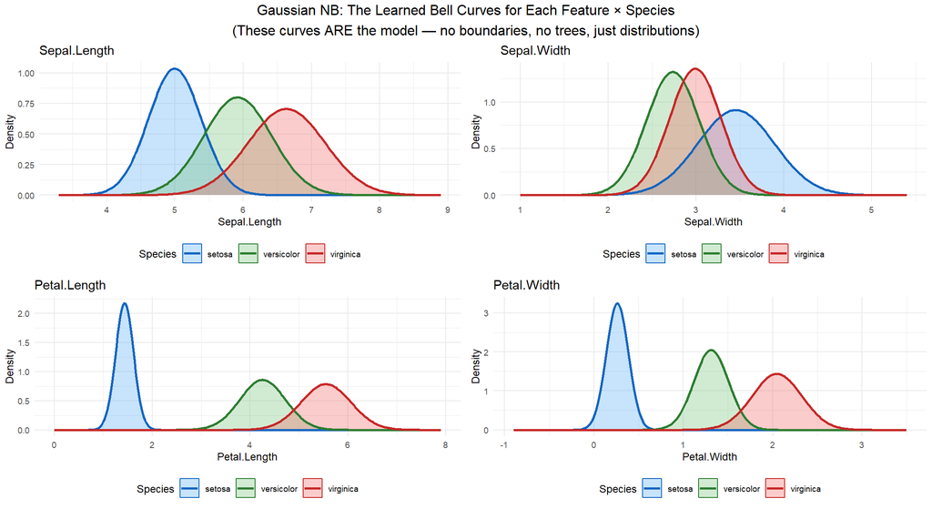

```r
param_list <- lapply(1:4, function(i) {
  feat <- names(iris)[i]
  tbl <- nb_model$tables[[i]]
  param_df <- data.frame(
    Species = rownames(tbl),
    Mean    = tbl[, 1],
    SD      = tbl[, 2]
  )

  x_range <- seq(min(iris[[feat]]) - 1, max(iris[[feat]]) + 1, length.out = 300)

  curves <- lapply(1:3, function(s) {
    data.frame(
      x = x_range,
      density = dnorm(x_range, param_df$Mean[s], param_df$SD[s]),
      Species = param_df$Species[s]
    )
  }) %>% do.call(rbind, .)

  ggplot(curves, aes(x = x, y = density, fill = Species, color = Species)) +
    geom_area(alpha = 0.3, position = "identity") +
    geom_line(linewidth = 0.9) +
    scale_fill_manual(values = c(setosa = "#42A5F5", versicolor = "#66BB6A", virginica = "#EF5350")) +
    scale_color_manual(values = c(setosa = "#1565C0", versicolor = "#2E7D32", virginica = "#C62828")) +
    labs(title = feat, x = feat, y = "Density") +
    theme_minimal(base_size = 9) +
    theme(legend.position = "bottom")
})

do.call(grid.arrange, c(param_list, ncol = 2,
  top = "Gaussian NB: The Learned Bell Curves for Each Feature × Species\n(These curves ARE the model — no boundaries, no trees, just distributions)"))
```

> **This is the entire model.** Unlike Decision Trees (which store a tree structure) or SVMs (which store support vectors), a Gaussian NB model is just a table of means and standard deviations. This makes it extremely compact and fast.

## 5.4 Prediction and Evaluation

```r
nb_pred <- predict(nb_model, iris_test)
nb_acc  <- mean(nb_pred == iris_test$Species)

cat(sprintf("Naive Bayes Test Accuracy: %.1f%%\n\n", nb_acc * 100))
```

```
## Naive Bayes Test Accuracy: 93.3%
```

```r
conf_mat <- table(Predicted = nb_pred, Actual = iris_test$Species)
print(conf_mat)
```

```
##             Actual
## Predicted    setosa versicolor virginica
##   setosa         19          0         0
##   versicolor      0         10         2
##   virginica       0          1        13
```

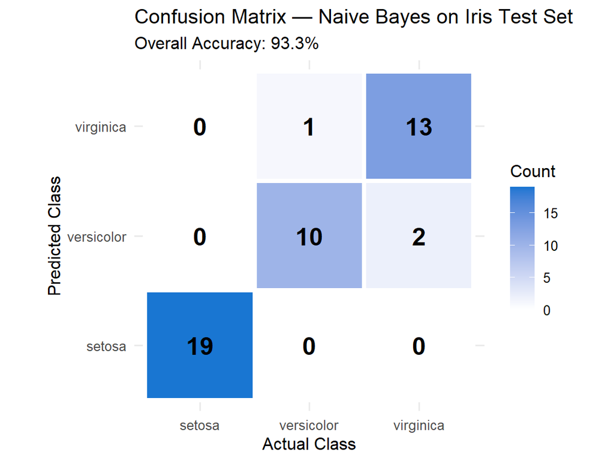

```r
conf_df <- as.data.frame(conf_mat)
names(conf_df) <- c("Predicted", "Actual", "Count")

ggplot(conf_df, aes(x = Actual, y = Predicted, fill = Count)) +
  geom_tile(color = "white", linewidth = 1.5) +
  geom_text(aes(label = Count), size = 6, fontface = "bold") +
  scale_fill_gradient(low = "white", high = "#1976D2") +
  labs(
    title = "Confusion Matrix — Naive Bayes on Iris Test Set",
    subtitle = sprintf("Overall Accuracy: %.1f%%", nb_acc * 100),
    x = "Actual Class", y = "Predicted Class"
  ) +
  theme_minimal(base_size = 12) +
  coord_equal()
```

## 5.5 Posterior Probabilities: How Confident Is the Model?

Unlike SVMs, Naive Bayes naturally produces **probability estimates** for each class.

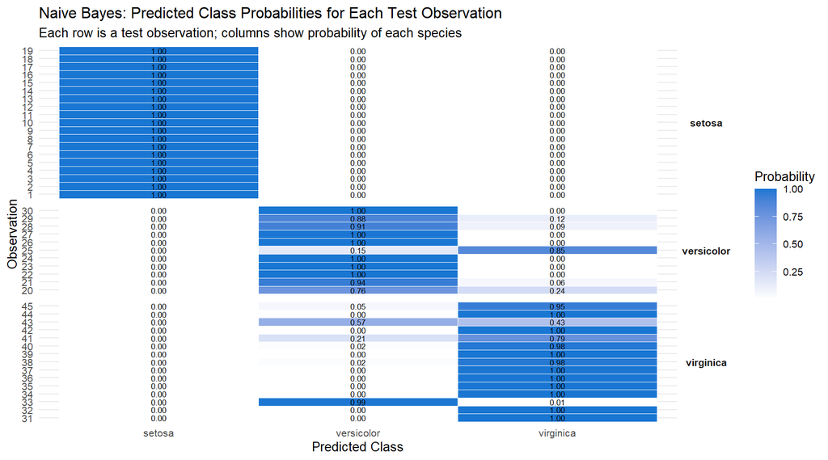

```r
nb_probs <- predict(nb_model, iris_test, type = "raw")

prob_df <- as.data.frame(nb_probs) %>%
  mutate(
    obs = 1:n(),
    actual = iris_test$Species,
    predicted = nb_pred,
    correct = (predicted == actual),
    confidence = apply(nb_probs, 1, max)
  )

prob_long <- prob_df %>%
  pivot_longer(cols = c(setosa, versicolor, virginica),
               names_to = "class", values_to = "prob")

ggplot(prob_long, aes(x = class, y = factor(obs), fill = prob)) +
  geom_tile(color = "white", linewidth = 0.3) +
  geom_text(aes(label = sprintf("%.2f", prob)), size = 2.2) +
  facet_grid(actual ~ ., scales = "free_y", space = "free") +
  scale_fill_gradient(low = "white", high = "#1976D2") +
  labs(
    title = "Naive Bayes: Predicted Class Probabilities for Each Test Observation",
    subtitle = "Each row is a test observation; columns show probability of each species",
    x = "Predicted Class", y = "Observation", fill = "Probability"
  ) +
  theme_minimal(base_size = 10) +
  theme(strip.text.y = element_text(angle = 0, face = "bold"))
```

## 5.6 Decision Boundary on Petal Features

Let’s visualise the decision regions — the same 2D view we used in Weeks 02-05 for a direct comparison.

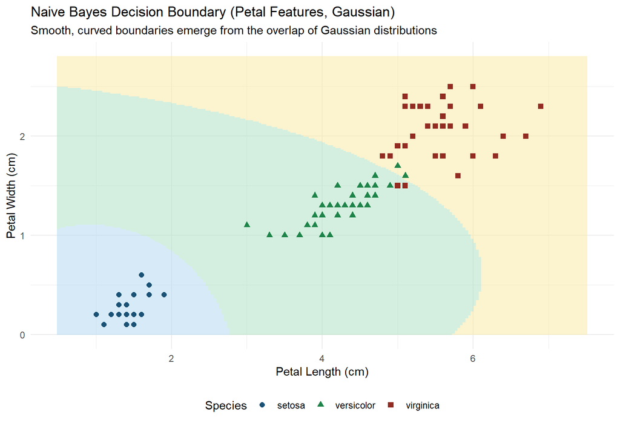

```r
iris_2d <- iris[, c("Petal.Length", "Petal.Width", "Species")]
train_2d <- iris_2d[train_idx, ]
test_2d  <- iris_2d[-train_idx, ]

nb_2d <- naiveBayes(Species ~ ., data = train_2d)

grid_nb <- expand.grid(
  Petal.Length = seq(0.5, 7.5, length.out = 200),
  Petal.Width  = seq(0, 2.8, length.out = 200)
)
grid_nb$pred <- predict(nb_2d, grid_nb)

palette_iris <- c(setosa = "#AED6F1", versicolor = "#A9DFBF", virginica = "#F9E79F")
point_colors <- c(setosa = "#1A5276", versicolor = "#1E8449", virginica = "#922B21")

ggplot() +
  geom_tile(data = grid_nb,
            aes(x = Petal.Length, y = Petal.Width, fill = pred), alpha = 0.5) +
  geom_point(data = train_2d,
             aes(x = Petal.Length, y = Petal.Width, color = Species, shape = Species),
             size = 2) +
  scale_fill_manual(values = palette_iris, guide = "none") +
  scale_color_manual(values = point_colors) +
  labs(
    title = "Naive Bayes Decision Boundary (Petal Features, Gaussian)",
    subtitle = "Smooth, curved boundaries emerge from the overlap of Gaussian distributions",
    x = "Petal Length (cm)", y = "Petal Width (cm)", color = "Species"
  ) +
  theme_minimal() +
  theme(legend.position = "bottom")
```

> **Compare with previous weeks:** Decision Trees create rectangular regions. Random Forests smooth those rectangles. SVMs draw curved margins around support vectors. Naive Bayes creates **smooth, elliptical** regions — reflecting the underlying Gaussian distributions.

# Part 6: The Zero-Frequency Problem & Laplace Smoothing

## 6.1 The Problem: A Single Zero Kills Everything

Suppose in our tennis dataset, “Overcast” weather **never** appears when Play = No. Then:

$$P(\text{Overcast} \mid \text{No}) =
0$$

Since Naive Bayes multiplies all feature probabilities together, **one zero wipes out the entire product** — no matter how strong the evidence from other features:

$$P(X \mid \text{No}) = 0 \times \ldots =
0$$

This is clearly wrong. Just because we haven’t *seen* a combination in training doesn’t mean it’s *impossible*.

## 6.2 The Fix: Laplace Smoothing (Add-One Smoothing)

The solution is simple: **add a small count** (typically 1) to every feature-class combination:

$$P(x_i \mid C_k) =
\frac{\text{count}(x_i, C_k) + \alpha}{\text{count}(C_k) + \alpha \times
n_i}$$

where $\alpha$ is the smoothing parameter (1 for Laplace smoothing) and $n_i$ is the number of possible values for feature $i$.

**Analogy:** Imagine you’re rating restaurants. You’ve eaten at Restaurant A ten times and loved it every time (10/10). Restaurant B is brand new — zero reviews. Does that mean Restaurant B has a 0% chance of being good? Of course not. Laplace smoothing is like giving every restaurant 1 positive and 1 negative review before anyone eats there — a modest starting point that gets overwhelmed by real data as reviews accumulate.

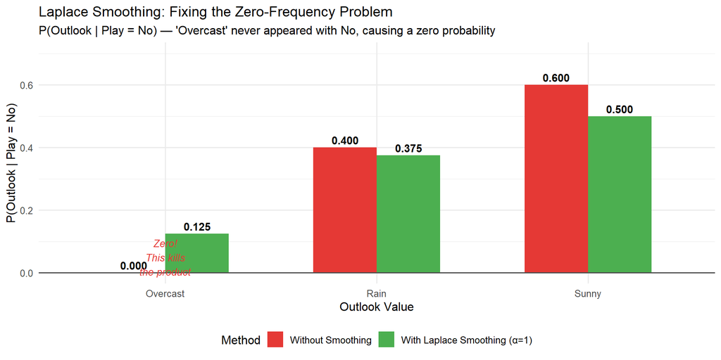

```r
outlook_vals <- c("Sunny", "Overcast", "Rain")

raw_counts_no <- sapply(outlook_vals, function(v) sum(tennis_no$Outlook == v))
raw_probs_no  <- raw_counts_no / no_count

alpha <- 1
n_categories <- length(outlook_vals)
smoothed_probs_no <- (raw_counts_no + alpha) / (no_count + alpha * n_categories)

smooth_df <- data.frame(
  Outlook = rep(outlook_vals, 2),
  Method  = rep(c("Without Smoothing", "With Laplace Smoothing (α=1)"), each = 3),
  Probability = c(raw_probs_no, smoothed_probs_no)
)
smooth_df$Method <- factor(smooth_df$Method,
                           levels = c("Without Smoothing", "With Laplace Smoothing (α=1)"))

ggplot(smooth_df, aes(x = Outlook, y = Probability, fill = Method)) +
  geom_col(position = "dodge", width = 0.6) +
  geom_text(aes(label = sprintf("%.3f", Probability)),
            position = position_dodge(width = 0.6), vjust = -0.4,
            fontface = "bold", size = 3.8) +
  scale_fill_manual(values = c("Without Smoothing" = "#E53935",
                                "With Laplace Smoothing (α=1)" = "#4CAF50")) +
  scale_y_continuous(limits = c(0, 0.7)) +
  geom_hline(yintercept = 0, color = "grey30") +
  annotate("text", x = "Overcast", y = 0.05,
           label = "Zero!\nThis kills\nthe product",
           color = "#E53935", fontface = "italic", size = 3.5) +
  labs(
    title = "Laplace Smoothing: Fixing the Zero-Frequency Problem",
    subtitle = "P(Outlook | Play = No) — 'Overcast' never appeared with No, causing a zero probability",
    x = "Outlook Value", y = "P(Outlook | Play = No)"
  ) +
  theme_minimal(base_size = 12) +
  theme(legend.position = "bottom")
```

> **Before smoothing:** P(Overcast | No) = 0 → entire product becomes 0. **After smoothing:** P(Overcast | No) = 0.125 → small but non-zero, allowing other features to still influence the decision.

## 6.3 How Smoothing Affects Predictions

The Smoothing Parameter α Controls How Much We Trust the Data vs. the Uniform Prior

| Alpha Value | Effect |
| --- | --- |
| α = 0 | No smoothing — zero probabilities possible, can crash the model |
| α = 1 (Laplace) | Standard fix — adds 1 pseudo-count to every category. Most common choice. |
| α < 1 (Lidstone) | Milder smoothing — useful when you have large training sets and want less bias |
| α → ∞ | All probabilities become 1/K (uniform) — the model ignores the data entirely |

# Part 7: Naive Bayes for Text Classification

## 7.1 The Bag-of-Words Model

Text classification is Naive Bayes’s most famous application. The idea:

1. **Tokenise** each document into individual words.
2. **Count** how often each word appears → a frequency vector.
3. Ignore word order (the “bag” metaphor — imagine dumping all words into a bag and shaking).
4. Apply Multinomial Naive Bayes to the word-count vectors.

## 7.2 A Spam Filtering Example

Let’s build a tiny spam filter from scratch to see the mechanics.

```r
set.seed(MASTER_SEED)

emails <- data.frame(
  text = c(
    "buy cheap pills now discount",
    "win free prize money today",
    "urgent offer limited time deal",
    "buy discount offer free shipping",
    "meeting tomorrow at the office",
    "lunch with team at noon today",
    "project deadline is next week",
    "please review the attached report",
    "can we schedule a meeting today",
    "free upgrade for your account now"
  ),
  label = c("spam","spam","spam","spam",
            "ham","ham","ham","ham","ham","spam")
)

knitr::kable(emails, col.names = c("Email Text", "Label"),
             caption = "A Tiny Email Corpus for Spam Classification")
```

A Tiny Email Corpus for Spam Classification

| Email Text | Label |
| --- | --- |
| buy cheap pills now discount | spam |
| win free prize money today | spam |
| urgent offer limited time deal | spam |
| buy discount offer free shipping | spam |
| meeting tomorrow at the office | ham |
| lunch with team at noon today | ham |
| project deadline is next week | ham |
| please review the attached report | ham |
| can we schedule a meeting today | ham |
| free upgrade for your account now | spam |

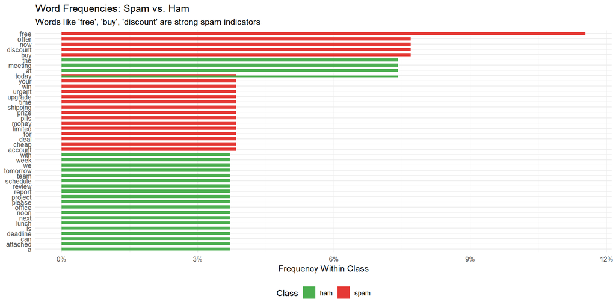

```r
all_words <- emails %>%
  mutate(words = strsplit(text, " ")) %>%
  unnest(words) %>%
  count(label, words) %>%
  group_by(label) %>%
  mutate(freq = n / sum(n)) %>%
  ungroup()

top_words <- all_words %>%
  group_by(words) %>%
  summarise(total = sum(n)) %>%
  top_n(15, total) %>%
  pull(words)

word_plot_df <- all_words %>% filter(words %in% top_words)

ggplot(word_plot_df, aes(x = reorder(words, freq), y = freq, fill = label)) +
  geom_col(position = "dodge", width = 0.6) +
  coord_flip() +
  scale_fill_manual(values = c(ham = "#4CAF50", spam = "#E53935")) +
  scale_y_continuous(labels = scales::percent) +
  labs(
    title = "Word Frequencies: Spam vs. Ham",
    subtitle = "Words like 'free', 'buy', 'discount' are strong spam indicators",
    x = NULL, y = "Frequency Within Class", fill = "Class"
  ) +
  theme_minimal(base_size = 11) +
  theme(legend.position = "bottom")
```

```r
spam_emails <- emails$text[emails$label == "spam"]
ham_emails  <- emails$text[emails$label == "ham"]

spam_words <- unlist(strsplit(paste(spam_emails, collapse = " "), " "))
ham_words  <- unlist(strsplit(paste(ham_emails, collapse = " "), " "))
vocabulary <- unique(c(spam_words, ham_words))
V <- length(vocabulary)

prior_spam_txt <- sum(emails$label == "spam") / nrow(emails)
prior_ham_txt  <- sum(emails$label == "ham") / nrow(emails)

# Laplace-smoothed word probabilities
p_word_spam <- sapply(vocabulary, function(w) {
  (sum(spam_words == w) + 1) / (length(spam_words) + V)
})
p_word_ham <- sapply(vocabulary, function(w) {
  (sum(ham_words == w) + 1) / (length(ham_words) + V)
})

# Classify a new email
new_email <- "free discount meeting today"
new_words <- strsplit(new_email, " ")[[1]]

log_spam <- log(prior_spam_txt) + sum(log(p_word_spam[new_words]), na.rm = TRUE)
log_ham  <- log(prior_ham_txt)  + sum(log(p_word_ham[new_words]), na.rm = TRUE)

cat(sprintf("New email: '%s'\n\n", new_email))
```

```
## New email: 'free discount meeting today'
```

```r
cat(sprintf("Log-score (spam): %.4f\n", log_spam))
```

```
## Log-score (spam): -14.3931
```

```r
cat(sprintf("Log-score (ham):  %.4f\n\n", log_ham))
```

```
## Log-score (ham):  -15.4323
```

```r
# Convert to probabilities using log-sum-exp trick
max_log <- max(log_spam, log_ham)
p_spam_new <- exp(log_spam - max_log) / (exp(log_spam - max_log) + exp(log_ham - max_log))
p_ham_new  <- 1 - p_spam_new

cat(sprintf("P(spam | email) = %.1f%%\n", p_spam_new * 100))
```

```
## P(spam | email) = 73.9%
```

```r
cat(sprintf("P(ham  | email) = %.1f%%\n", p_ham_new * 100))
```

```
## P(ham  | email) = 26.1%
```

```r
cat(sprintf("Prediction: %s\n", ifelse(p_spam_new > p_ham_new, "SPAM", "HAM")))
```

```
## Prediction: SPAM
```

> **Note:** We use **log-probabilities** instead of raw probabilities. Multiplying many small numbers leads to numerical underflow (the result becomes indistinguishable from zero). Taking logarithms converts products to sums, avoiding this problem.

# Part 8: Model Comparison — NB vs. Everything Else

## 8.1 Decision Boundaries: Four Models Side by Side

Let’s put all four classification methods we’ve learned on the same 2D Iris task.

```r
set.seed(MASTER_SEED)

grid_comp <- expand.grid(
  Petal.Length = seq(0.5, 7.5, length.out = 200),
  Petal.Width  = seq(0, 2.8, length.out = 200)
)
```

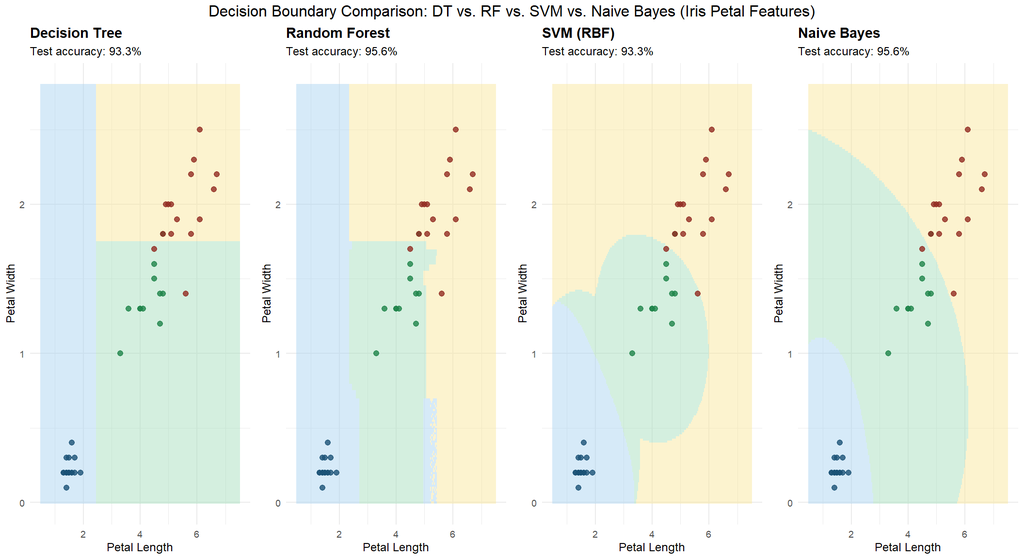

Test Accuracy Comparison on Iris Petal Features

| Model | Test Accuracy (%) |
| --- | --- |
| Decision Tree | 93.3 |
| Random Forest | 95.6 |
| SVM (RBF) | 93.3 |
| Naive Bayes | 95.6 |

```r
# Decision Tree
dt_comp <- rpart(Species ~ Petal.Length + Petal.Width, data = train_2d,
                 method = "class", control = rpart.control(maxdepth = 4))

# Random Forest
rf_comp <- randomForest(Species ~ Petal.Length + Petal.Width, data = train_2d, ntree = 200)

# SVM (RBF)
svm_comp <- svm(Species ~ Petal.Length + Petal.Width, data = train_2d,
                kernel = "radial", cost = 5, gamma = 1, scale = TRUE)

# Naive Bayes (already trained as nb_2d)

models_list <- list(
  list(name = "Decision Tree",  pred_fn = function(g) predict(dt_comp, g, type = "class")),
  list(name = "Random Forest",  pred_fn = function(g) predict(rf_comp, g)),
  list(name = "SVM (RBF)",      pred_fn = function(g) predict(svm_comp, g)),
  list(name = "Naive Bayes",    pred_fn = function(g) predict(nb_2d, g))
)

plots_comp <- lapply(models_list, function(item) {
  grid_comp$pred <- item$pred_fn(grid_comp)
  test_pred <- item$pred_fn(test_2d)
  test_acc  <- mean(test_pred == test_2d$Species)

  ggplot() +
    geom_tile(data = grid_comp, aes(x = Petal.Length, y = Petal.Width, fill = pred), alpha = 0.5) +
    geom_point(data = test_2d, aes(x = Petal.Length, y = Petal.Width, color = Species),
               size = 1.8, alpha = 0.8) +
    scale_fill_manual(values = palette_iris, guide = "none") +
    scale_color_manual(values = point_colors, guide = "none") +
    labs(
      title = item$name,
      subtitle = sprintf("Test accuracy: %.1f%%", test_acc * 100),
      x = "Petal Length", y = "Petal Width"
    ) +
    theme_minimal(base_size = 9) +
    theme(plot.title = element_text(face = "bold"))
})

do.call(grid.arrange, c(plots_comp, ncol = 4,
  top = "Decision Boundary Comparison: DT vs. RF vs. SVM vs. Naive Bayes (Iris Petal Features)"))
```

## 8.2 Boundary Shape Comparison

How Each Model Creates Its Decision Boundary

| Model | Boundary Shape | What Drives It |
| --- | --- | --- |
| Decision Tree | Rectangular, axis-aligned — each split is a horizontal or vertical line | Greedy, one-feature-at-a-time splits |
| Random Forest | Smoothed rectangles — averaging many trees softens the edges | Averaging over hundreds of diverse trees |
| SVM (RBF) | Smooth, curved margins — the kernel trick creates flexible boundaries | Maximising the margin between support vectors |
| Naive Bayes (Gaussian) | Smooth, elliptical — boundaries follow the contours of Gaussian distributions | The intersection of class-conditional probability density curves |

## 8.3 Training Speed Comparison

One of Naive Bayes’s biggest advantages is speed.

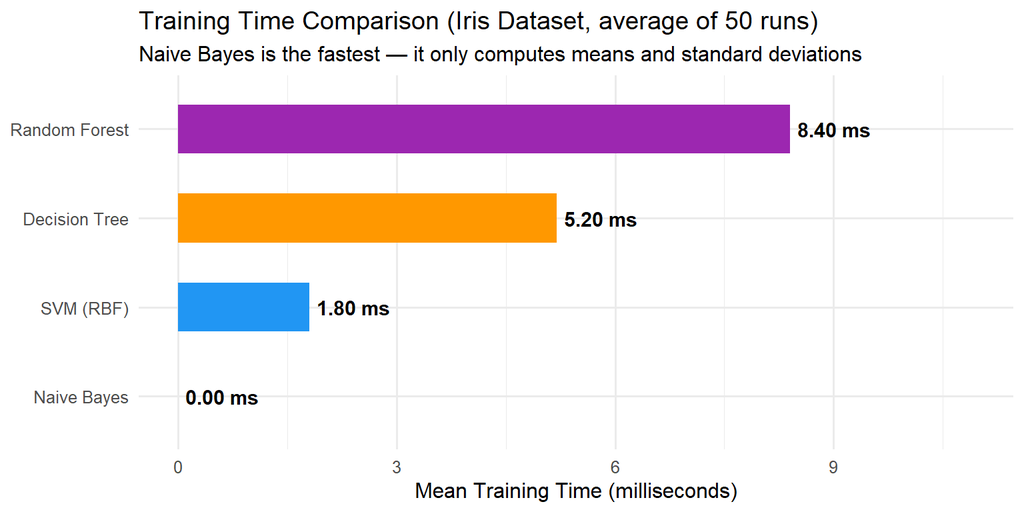

```r
set.seed(MASTER_SEED)

n_reps <- 50
times <- data.frame(
  Model = character(),
  Time_ms = numeric()
)

for (r in 1:n_reps) {
  t_nb  <- system.time(naiveBayes(Species ~ ., data = iris_train))["elapsed"]
  t_dt  <- system.time(rpart(Species ~ ., data = iris_train, method = "class"))["elapsed"]
  t_rf  <- system.time(randomForest(Species ~ ., data = iris_train, ntree = 200))["elapsed"]
  t_svm <- system.time(svm(Species ~ ., data = iris_train, kernel = "radial"))["elapsed"]

  times <- rbind(times, data.frame(
    Model = c("Naive Bayes", "Decision Tree", "Random Forest", "SVM (RBF)"),
    Time_ms = c(t_nb, t_dt, t_rf, t_svm) * 1000
  ))
}

time_summary <- times %>%
  group_by(Model) %>%
  summarise(Mean_ms = mean(Time_ms), .groups = "drop") %>%
  mutate(Model = factor(Model, levels = c("Naive Bayes", "Decision Tree", "SVM (RBF)", "Random Forest")))

ggplot(time_summary, aes(x = reorder(Model, Mean_ms), y = Mean_ms, fill = Model)) +
  geom_col(width = 0.55) +
  geom_text(aes(label = sprintf("%.2f ms", Mean_ms)),
            hjust = -0.1, fontface = "bold", size = 4) +
  coord_flip(xlim = NULL, ylim = c(0, max(time_summary$Mean_ms) * 1.3)) +
  scale_fill_manual(values = c(
    "Naive Bayes"   = "#4CAF50",
    "Decision Tree" = "#FF9800",
    "SVM (RBF)"     = "#2196F3",
    "Random Forest" = "#9C27B0"
  )) +
  labs(
    title = "Training Time Comparison (Iris Dataset, average of 50 runs)",
    subtitle = "Naive Bayes is the fastest — it only computes means and standard deviations",
    x = NULL, y = "Mean Training Time (milliseconds)"
  ) +
  theme_minimal(base_size = 12) +
  theme(legend.position = "none")
```

> **Why is NB so fast?** Training a Gaussian NB model requires only **one pass** through the data to compute the mean and standard deviation of each feature for each class. There is no iterative optimisation, no tree-building, no kernel computation. For $n$ samples, $p$ features, and $K$ classes, the training complexity is $O(n \times p \times K)$.

# Part 9: Advantages, Disadvantages & Practical Tips

## 9.1 When to Use Naive Bayes

Naive Bayes: Strengths and Weaknesses

| Property | Naive Bayes Assessment |
| --- | --- |
| Training speed | Excellent — one of the fastest classifiers to train (just compute means and counts) |
| Prediction speed | Excellent — prediction is a simple product of probabilities |
| Small training sets | Excellent — few parameters means less overfitting with limited data |
| High-dimensional data | Good — handles thousands of features (e.g., word vocabularies) without trouble |
| Text classification | Excellent — Multinomial NB is the classic baseline for spam filtering and document classification |
| Probability estimates | Native — NB directly outputs class probabilities (unlike SVM which needs Platt scaling) |
| Feature independence | Poor assumption — features are rarely independent; model still works but probabilities may be poorly calibrated |
| Continuous features | Moderate — Gaussian assumption may not hold; consider discretising or using kernel density estimation |
| Complex decision boundaries | Limited — boundaries are always smooth ellipses (Gaussian) or linear (Multinomial), cannot capture XOR-like patterns |
| Outlier robustness | Moderate — less robust than tree-based methods to extreme outliers |
| Feature scaling required | Not required — NB is not distance-based, so feature scaling does not affect results |